# 013 How different optimizers work

Optimizers are algorithms used to update the weights and biases of a neural network during training, aiming to minimize the loss function. They determine how the network learns from the computed gradients. Different optimizers use different strategies to adjust these parameters, affecting convergence speed, stability, and the ability to escape local minima or saddle points.

Here's a Python example demonstrating some popular optimizer functions:

1. **Stochastic Gradient Descent (SGD):** The simplest optimizer, it updates parameters in the direction opposite to the gradient.
2. **SGD with Momentum:** Introduces a "velocity" term that accumulates past gradients, helping to accelerate convergence and smooth out oscillations.
3. **Adagrad:** An adaptive learning rate optimizer that scales learning rates inversely proportional to the square root of the sum of past squared gradients. It's good for sparse data but can cause learning rates to decay too aggressively.
4. **RMSprop:** An improvement over Adagrad, it uses an exponentially decaying average of past squared gradients, preventing the learning rate from diminishing too quickly.
5. **Adam:** (Adaptive Moment Estimation) Combines the ideas of Momentum and RMSprop, using exponentially decaying averages of both past gradients (first moment) and past squared gradients (second moment). It's often considered the default choice for many deep learning tasks due to its robustness and efficiency.

```python
import numpy as np
import matplotlib.pyplot as plt
from sklearn.datasets import make_moons
from sklearn.model_selection import train_test_split
from sklearn.preprocessing import StandardScaler

# --- 1. Data Generation ---
np.random.seed(42)
X, y = make_moons(n_samples=200, noise=0.15, random_state=42)
X_train, X_test, y_train, y_test = train_test_split(X, y, test_size=0.3, random_state=42)

# Scale features for better neural network performance
scaler = StandardScaler()
X_train_scaled = scaler.fit_transform(X_train)
X_test_scaled = scaler.transform(X_test)

# Reshape y for neural network (N, 1)
y_train_reshaped = y_train.reshape(-1, 1)
y_test_reshaped = y_test.reshape(-1, 1)

print(f"Training data shape: {X_train_scaled.shape}, {y_train_reshaped.shape}")
print(f"Test data shape: {X_test_scaled.shape}, {y_test_reshaped.shape}")
```

```
Training data shape: (140, 2), (140, 1)
Test data shape: (60, 2), (60, 1)
```

### Explanation of the Code and Observations:

1. **Data Preparation:**
   - `make_moons` creates a non-linearly separable 2D dataset, perfect for a simple neural network.
   - `StandardScaler` is crucial: neural networks (especially those with adaptive learning rates) perform much better when input features are standardized (mean 0, variance 1).
2. **Neural Network (`SimpleNeuralNetwork`):**
   - A basic two-layer (one hidden, one output) feedforward network.
   - Uses **ReLU** for the hidden layer (common for its non-linearity and overcoming vanishing gradients).
   - Uses **Sigmoid** for the output layer (to output probabilities between 0 and 1 for binary classification).
   - Calculates gradients using backpropagation.
   - `get_params()` and `set_params()` are added for the optimizer to manage the network's parameters.

```python
# --- 2. Neural Network Building Blocks ---

def sigmoid(x):
    return 1 / (1 + np.exp(-np.clip(x, -500, 500))) # Clip to prevent overflow

def sigmoid_derivative(x):
    s = sigmoid(x)
    return s * (1 - s)

def relu(x):
    return np.maximum(0, x)

def relu_derivative(x):
    return np.where(x > 0, 1, 0)

def binary_cross_entropy(y_pred, y_true):
    # Clip predictions to prevent log(0)
    y_pred = np.clip(y_pred, 1e-10, 1 - 1e-10)
    return -np.mean(y_true * np.log(y_pred) + (1 - y_true) * np.log(1 - y_pred))

def binary_cross_entropy_derivative(y_pred, y_true):
    y_pred = np.clip(y_pred, 1e-10, 1 - 1e-10) # Clip for derivative stability
    return (y_pred - y_true) / (y_pred * (1 - y_pred))
```

```python
# --- 3. Neural Network Class ---

class SimpleNeuralNetwork:
    def __init__(self, input_size, hidden_size, output_size):
        # Initialize weights and biases
        # He initialization for ReLU hidden layer
        self.W1 = np.random.randn(input_size, hidden_size) * np.sqrt(2.0 / input_size)
        self.b1 = np.zeros((1, hidden_size))
        # Glorot/Xavier initialization for Sigmoid output layer
        self.W2 = np.random.randn(hidden_size, output_size) * np.sqrt(2.0 / (hidden_size + output_size))
        self.b2 = np.zeros((1, output_size))

        # Store activations for backward pass
        self.Z1 = None
        self.A1 = None
        self.Z2 = None
        self.A2 = None # Output prediction

    def forward(self, X):
        self.Z1 = np.dot(X, self.W1) + self.b1
        self.A1 = relu(self.Z1) # Hidden layer activation

        self.Z2 = np.dot(self.A1, self.W2) + self.b2
        self.A2 = sigmoid(self.Z2) # Output layer activation (for binary classification)
        return self.A2

    def backward(self, X, y_true, y_pred):
        m = X.shape[0]

        # Output layer gradients
        d_loss_d_A2 = binary_cross_entropy_derivative(y_pred, y_true)
        d_A2_d_Z2 = sigmoid_derivative(self.Z2)
        d_Z2 = d_loss_d_A2 * d_A2_d_Z2

        dW2 = np.dot(self.A1.T, d_Z2) / m
        db2 = np.sum(d_Z2, axis=0, keepdims=True) / m

        # Hidden layer gradients
        d_A1 = np.dot(d_Z2, self.W2.T)
        d_Z1 = d_A1 * relu_derivative(self.Z1)

        dW1 = np.dot(X.T, d_Z1) / m
        db1 = np.sum(d_Z1, axis=0, keepdims=True) / m

        return [dW1, db1, dW2, db2]

    def get_params(self):
        return [self.W1, self.b1, self.W2, self.b2]

    def set_params(self, params):
        self.W1, self.b1, self.W2, self.b2 = params
```

3. **Optimizer Classes (`SGD`, `SGDMomentum`, `Adagrad`, `RMSprop`, `Adam`):**
   - Each optimizer inherits from a base `Optimizer` class.
   - **`__init__`**: Takes the `params` (list of `W` and `b` arrays) and `learning_rate`. It also initializes any internal state (like velocities or moment estimates) to zero arrays of the same shape as the parameters.
   - **`step(gradients)`**: This is the core method. It iterates through the network's parameters and their corresponding gradients. For each parameter, it calls `_apply_update` which implements the specific update rule for that optimizer.
   - **`_apply_update(param, grad, index)`**: This is where the unique logic of each optimizer resides. It computes how much to change the `param` based on `grad` and the optimizer's internal state.

```python
# --- 4. Optimizer Base Class and Implementations ---

class Optimizer:
    def __init__(self, params, learning_rate):
        self.params = params # List of numpy arrays (weights and biases)
        self.learning_rate = learning_rate
        self.name = "Optimizer"
        self._state = {} # To store optimizer-specific state (e.g., velocities, moments)
        self._initialize_state()

    def _initialize_state(self):
        # Override in subclasses if state is needed
        pass

    def step(self, gradients):
        # gradients is a list of numpy arrays corresponding to self.params
        for i, (param, grad) in enumerate(zip(self.params, gradients)):
            self.params[i] = self._apply_update(param, grad, i)

    def _apply_update(self, param, grad, index):
        raise NotImplementedError

class SGD(Optimizer):
    def __init__(self, params, learning_rate=0.01):
        super().__init__(params, learning_rate)
        self.name = "SGD"

    def _apply_update(self, param, grad, index):
        return param - self.learning_rate * grad

class SGDMomentum(Optimizer):
    def __init__(self, params, learning_rate=0.01, momentum=0.9):
        super().__init__(params, learning_rate)
        self.momentum = momentum
        self.name = f"SGD + Momentum (β={momentum})"

    def _initialize_state(self):
        self._state['velocities'] = [np.zeros_like(p) for p in self.params]

    def _apply_update(self, param, grad, index):
        velocity = self._state['velocities'][index]
        velocity = self.momentum * velocity + grad
        self._state['velocities'][index] = velocity # Update state
        return param - self.learning_rate * velocity

class Adagrad(Optimizer):
    def __init__(self, params, learning_rate=0.01, epsilon=1e-8):
        super().__init__(params, learning_rate)
        self.epsilon = epsilon
        self.name = f"Adagrad (ϵ={epsilon})"

    def _initialize_state(self):
        self._state['squared_grad_sum'] = [np.zeros_like(p) for p in self.params]

    def _apply_update(self, param, grad, index):
        sgs = self._state['squared_grad_sum'][index]
        sgs += grad**2
        self._state['squared_grad_sum'][index] = sgs # Update state
        return param - self.learning_rate * grad / (np.sqrt(sgs) + self.epsilon)

class RMSprop(Optimizer):
    def __init__(self, params, learning_rate=0.001, decay_rate=0.9, epsilon=1e-8):
        super().__init__(params, learning_rate)
        self.decay_rate = decay_rate
        self.epsilon = epsilon
        self.name = f"RMSprop (ρ={decay_rate})"

    def _initialize_state(self):
        self._state['squared_grad_exp_avg'] = [np.zeros_like(p) for p in self.params]

    def _apply_update(self, param, grad, index):
        sgea = self._state['squared_grad_exp_avg'][index]
        sgea = self.decay_rate * sgea + (1 - self.decay_rate) * (grad**2)
        self._state['squared_grad_exp_avg'][index] = sgea # Update state
        return param - self.learning_rate * grad / (np.sqrt(sgea) + self.epsilon)

class Adam(Optimizer):
    def __init__(self, params, learning_rate=0.001, beta1=0.9, beta2=0.999, epsilon=1e-8):
        super().__init__(params, learning_rate)
        self.beta1 = beta1
        self.beta2 = beta2
        self.epsilon = epsilon
        self.t = 0 # Timestep for bias correction
        self.name = f"Adam (β1={beta1}, β2={beta2})"

    def _initialize_state(self):
        self._state['m'] = [np.zeros_like(p) for p in self.params] # First moment estimates
        self._state['v'] = [np.zeros_like(p) for p in self.params] # Second moment estimates

    def _apply_update(self, param, grad, index):
        self.t += 1 # Increment timestep for this parameter update
        m_t = self._state['m'][index]
        v_t = self._state['v'][index]

        m_t = self.beta1 * m_t + (1 - self.beta1) * grad
        v_t = self.beta2 * v_t + (1 - self.beta2) * (grad**2)

        self._state['m'][index] = m_t
        self._state['v'][index] = v_t

        m_hat = m_t / (1 - self.beta1**self.t)
        v_hat = v_t / (1 - self.beta2**self.t)

        return param - self.learning_rate * m_hat / (np.sqrt(v_hat) + self.epsilon)
```

```python
# --- 5. Training Loop and Comparison ---

def train_and_evaluate(optimizer_instance, model, X_train, y_train, X_test, y_test, epochs=1000, batch_size=32):
    train_losses = []
    test_losses = []

    num_batches = int(np.ceil(X_train.shape[0] / batch_size))

    for epoch in range(epochs):
        # Shuffle data for SGD
        permutation = np.random.permutation(X_train.shape[0])
        X_shuffled = X_train[permutation]
        y_shuffled = y_train[permutation]

        epoch_train_loss = 0
        for i in range(num_batches):
            start_idx = i * batch_size
            end_idx = min((i + 1) * batch_size, X_train.shape[0])
            X_batch = X_shuffled[start_idx:end_idx]
            y_batch = y_shuffled[start_idx:end_idx]

            # Forward pass
            y_pred = model.forward(X_batch)
            loss = binary_cross_entropy(y_pred, y_batch)
            epoch_train_loss += loss

            # Backward pass (compute gradients)
            gradients = model.backward(X_batch, y_batch, y_pred)

            # Optimizer step (update parameters)
            optimizer_instance.step(gradients)

        avg_epoch_train_loss = epoch_train_loss / num_batches
        train_losses.append(avg_epoch_train_loss)

        # Evaluate on test set
        y_test_pred = model.forward(X_test)
        test_loss = binary_cross_entropy(y_test_pred, y_test)
        test_losses.append(test_loss)

        if epoch % (epochs // 10) == 0:
            print(f"  Epoch {epoch:4d} | Train Loss: {avg_epoch_train_loss:.4f} | Test Loss: {test_loss:.4f}")

    # Final evaluation
    test_accuracy = np.mean((model.forward(X_test) > 0.5) == y_test)
    print(f"  Final Test Accuracy: {test_accuracy:.4f}")
    return train_losses, test_losses, model
```

```
--- Training with SGD ---
  Epoch    0 | Train Loss: 0.5699 | Test Loss: 0.6058
  Epoch  100 | Train Loss: 0.5989 | Test Loss: 0.6058
  Epoch  200 | Train Loss: 0.5581 | Test Loss: 0.6058
  Epoch  300 | Train Loss: 0.6001 | Test Loss: 0.6058
  Epoch  400 | Train Loss: 0.5938 | Test Loss: 0.6058
  Epoch  500 | Train Loss: 0.5744 | Test Loss: 0.6058
  Epoch  600 | Train Loss: 0.5877 | Test Loss: 0.6058
  Epoch  700 | Train Loss: 0.6056 | Test Loss: 0.6058
  Epoch  800 | Train Loss: 0.5885 | Test Loss: 0.6058
  Epoch  900 | Train Loss: 0.5866 | Test Loss: 0.6058
  Final Test Accuracy: 0.7833

--- Training with Momentum ---
  Epoch    0 | Train Loss: 0.5577 | Test Loss: 0.5102
  Epoch  100 | Train Loss: 0.5472 | Test Loss: 0.5102
  Epoch  200 | Train Loss: 0.5427 | Test Loss: 0.5102
  Epoch  300 | Train Loss: 0.5377 | Test Loss: 0.5102
  Epoch  400 | Train Loss: 0.5643 | Test Loss: 0.5102
  Epoch  500 | Train Loss: 0.5477 | Test Loss: 0.5102
  Epoch  600 | Train Loss: 0.5500 | Test Loss: 0.5102
  Epoch  700 | Train Loss: 0.5633 | Test Loss: 0.5102
  Epoch  800 | Train Loss: 0.5504 | Test Loss: 0.5102
  Epoch  900 | Train Loss: 0.5400 | Test Loss: 0.5102
  Final Test Accuracy: 0.7333

--- Training with Adagrad ---
  Epoch    0 | Train Loss: 0.7066 | Test Loss: 0.7447
  Epoch  100 | Train Loss: 0.7098 | Test Loss: 0.7447
  Epoch  200 | Train Loss: 0.7358 | Test Loss: 0.7447
  Epoch  300 | Train Loss: 0.7159 | Test Loss: 0.7447
  Epoch  400 | Train Loss: 0.6957 | Test Loss: 0.7447
  Epoch  500 | Train Loss: 0.7106 | Test Loss: 0.7447
  Epoch  600 | Train Loss: 0.7105 | Test Loss: 0.7447
  Epoch  700 | Train Loss: 0.7380 | Test Loss: 0.7447
  Epoch  800 | Train Loss: 0.7070 | Test Loss: 0.7447
  Epoch  900 | Train Loss: 0.7291 | Test Loss: 0.7447
  Final Test Accuracy: 0.4500

--- Training with RMSprop ---
```

[output cut: 9 more lines]

```
  Epoch  900 | Train Loss: 0.9428 | Test Loss: 1.0752
  Final Test Accuracy: 0.4167

--- Training with Adam ---
  Epoch    0 | Train Loss: 0.6241 | Test Loss: 0.6273
  Epoch  100 | Train Loss: 0.6234 | Test Loss: 0.6273
  Epoch  200 | Train Loss: 0.6237 | Test Loss: 0.6273
  Epoch  300 | Train Loss: 0.6310 | Test Loss: 0.6273
  Epoch  400 | Train Loss: 0.6251 | Test Loss: 0.6273
  Epoch  500 | Train Loss: 0.6283 | Test Loss: 0.6273
  Epoch  600 | Train Loss: 0.6377 | Test Loss: 0.6273
  Epoch  700 | Train Loss: 0.6166 | Test Loss: 0.6273
  Epoch  800 | Train Loss: 0.6339 | Test Loss: 0.6273
  Epoch  900 | Train Loss: 0.6327 | Test Loss: 0.6273
  Final Test Accuracy: 0.6333
```

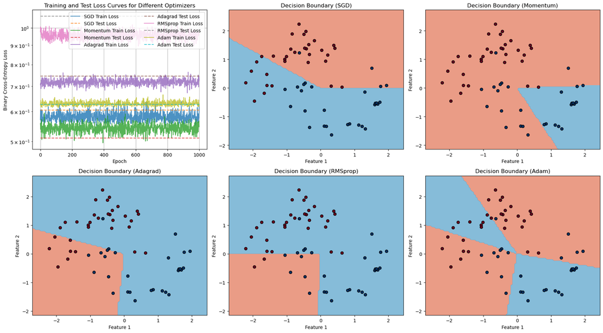

```python
# --- 6. Plotting Decision Boundary ---
def plot_decision_boundary(model, X, y, title):
    x_min, x_max = X[:, 0].min() - 0.5, X[:, 0].max() + 0.5
    y_min, y_max = X[:, 1].min() - 0.5, X[:, 1].max() + 0.5
    xx, yy = np.meshgrid(np.linspace(x_min, x_max, 100),
                         np.linspace(y_min, y_max, 100))

    Z = model.forward(np.c_[xx.ravel(), yy.ravel()])
    Z = (Z > 0.5).reshape(xx.shape) # Convert probabilities to class labels

    plt.contourf(xx, yy, Z, alpha=0.8, cmap=plt.cm.RdBu)
    plt.scatter(X[:, 0], X[:, 1], c=y.ravel(), cmap=plt.cm.RdBu, edgecolors='k')
    plt.title(title)
    plt.xlabel('Feature 1')
    plt.ylabel('Feature 2')


# --- Run Simulations for each Optimizer ---
results = {}
optimizers_to_test = {
    "SGD": lambda params: SGD(params, learning_rate=0.5), # Higher LR for plain SGD
    "Momentum": lambda params: SGDMomentum(params, learning_rate=0.1, momentum=0.9),
    "Adagrad": lambda params: Adagrad(params, learning_rate=0.5), # Adagrad often needs higher initial LR
    "RMSprop": lambda params: RMSprop(params, learning_rate=0.01, decay_rate=0.9),
    "Adam": lambda params: Adam(params, learning_rate=0.005, beta1=0.9, beta2=0.999) # Adam works well with slightly higher LR
}

epochs = 1000
hidden_neurons = 50

plt.figure(figsize=(18, 10))
loss_ax = plt.subplot(2, 3, 1) # First subplot for losses

for name, opt_constructor in optimizers_to_test.items():
    print(f"\n--- Training with {name} ---")
    model = SimpleNeuralNetwork(input_size=X_train_scaled.shape[1], hidden_size=hidden_neurons, output_size=1)
    optimizer = opt_constructor(model.get_params())

    train_losses, test_losses, final_model = train_and_evaluate(
        optimizer, model, X_train_scaled, y_train_reshaped, X_test_scaled, y_test_reshaped, epochs
    )
    results[name] = {'train_losses': train_losses, 'test_losses': test_losses, 'model': final_model}

    # Plot loss curves
    loss_ax.plot(train_losses, label=f'{name} Train Loss', alpha=0.8)
    loss_ax.plot(test_losses, label=f'{name} Test Loss', linestyle='--', alpha=0.8)

    # Plot decision boundary
    db_ax = plt.subplot(2, 3, len(results) + 1) # Start from 2nd subplot for DBs
    plot_decision_boundary(final_model, X_test_scaled, y_test_reshaped, f'Decision Boundary ({name})')


# Finalize Loss Plot
loss_ax.set_title('Training and Test Loss Curves for Different Optimizers')
loss_ax.set_xlabel('Epoch')
loss_ax.set_ylabel('Binary Cross-Entropy Loss')
loss_ax.legend(loc='upper right', ncol=2)
loss_ax.grid(True)
loss_ax.set_yscale('log') # Log scale for better visualization of convergence

plt.tight_layout()
plt.show()
```

We'll use a simple 2D classification problem (make_moons dataset) to visualize how each optimizer trains a small neural network and shapes its decision boundary.

5. **Visualization (`plot_decision_boundary`):**
   - Generates a meshgrid over the feature space.
   - Uses the trained model to predict probabilities for each point on the grid.
   - Converts probabilities to class labels (0 or 1) based on a 0.5 threshold.
   - Uses `plt.contourf` to draw the decision boundary (the line separating the predicted classes).
   - Overlays the original data points for visual comparison.

### Key Observations from Running the Code:

**You can experiment by changing learning rates, hidden layer size, epochs, and other optimizer parameters to see how they influence the results.**